# Data_Analysis_#2

## Loading in packages & data

```r
# Load Tidyverse, janitor and arcos, tidycensus, mapview, ggthemes, scales

library(tidyverse)
library(janitor)
library(tidycensus)

library(arcos)

library(mapview)
library(ggthemes)
library(scales)
```

## Storing key to load in data

```r
# store one of our API keys as an object called key
key <- "uO4EK6I"
```

## Loading in data

```r
pills_county_month <- read_csv("pills_county_month.csv")
pills_county_month <- clean_names(pills_county_month)

pills_county_month_year <- read_csv("pills_county_month_year.csv")
pills_county_month_year <- clean_names(pills_county_month_year)

pills_state <- read_csv("pills_state.csv")
pills_state <- clean_names(pills_state)

pills_state_month <- read_csv("pills_state_month.csv")
pills_state_month <- clean_names(pills_state_month)
```

1. Can the pills dip in January be seen at the national level?

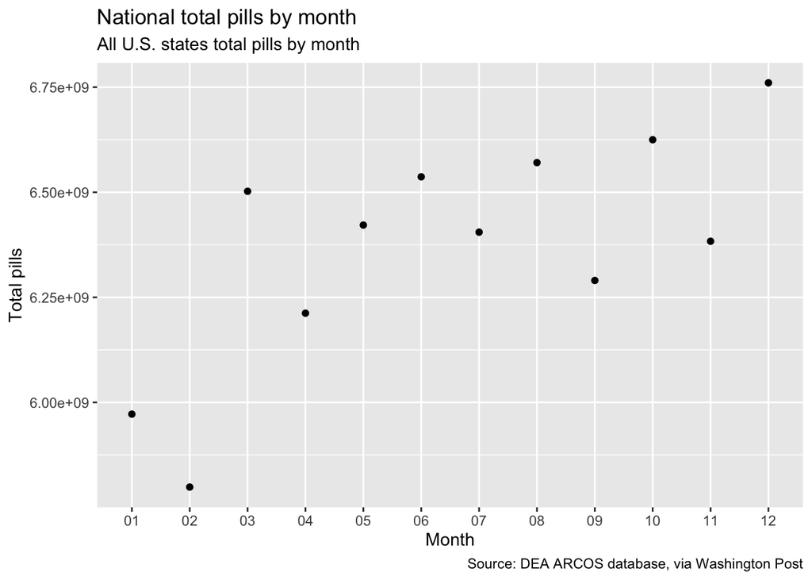

```r
pills_state_monthRE <- pills_state_month %>%
  group_by(month) %>%
  summarise(total_pills = sum(total_pills))

ggplot(pills_state_monthRE) +
 geom_point(aes(month, total_pills)) +
 labs(x="Month", y="Total pills", title="National total pills by month", subtitle = "All U.S. states total pills by month", caption = "Source: DEA ARCOS database, via Washington Post")
```

```r
  options(scipen=999)
```

```r
pills_state_monthCH <- pivot_wider(pills_state_month, id_cols = buyer_state, names_from = month,
  values_from = total_pills, values_fill = NULL, values_fn = NULL)
```

```r
pills_state_monthCH
```

```
## # A tibble: 51 x 13
##    buyer_state   `01`   `02`   `03`   `04`   `05`   `06`   `07`   `08`
##    <chr>        <dbl>  <dbl>  <dbl>  <dbl>  <dbl>  <dbl>  <dbl>  <dbl>
##  1 AL          1.26e8 1.26e8 1.41e8 1.37e8 1.47e8 1.47e8 1.44e8 1.44e8
##  2 AK          1.10e7 1.03e7 1.16e7 1.12e7 1.17e7 1.18e7 1.18e7 1.20e7
##  3 AZ          1.31e8 1.33e8 1.50e8 1.40e8 1.44e8 1.44e8 1.41e8 1.47e8
##  4 AR          6.95e7 6.66e7 7.41e7 7.34e7 7.56e7 7.65e7 7.54e7 7.66e7
##  5 CA          6.43e8 6.13e8 6.91e8 6.61e8 6.66e8 6.87e8 6.71e8 6.80e8
##  6 CO          7.73e7 7.73e7 8.79e7 8.18e7 8.50e7 8.65e7 8.60e7 8.87e7
##  7 CT          5.33e7 5.07e7 5.74e7 5.39e7 5.63e7 5.96e7 5.65e7 5.77e7
##  8 DC          4.50e6 4.47e6 5.19e6 4.92e6 4.81e6 5.14e6 4.82e6 4.98e6
##  9 DE          2.15e7 2.11e7 2.39e7 2.22e7 2.33e7 2.37e7 2.32e7 2.37e7
## 10 FL          4.53e8 4.38e8 4.87e8 4.66e8 4.72e8 4.72e8 4.52e8 4.63e8
## # … with 41 more rows, and 4 more variables: `09` <dbl>, `10` <dbl>,
## #   `11` <dbl>, `12` <dbl>
```

```r
pills_state_monthCH %>%
      select(buyer_state, "01","12")
```

```
## # A tibble: 51 x 3
##    buyer_state       `01`       `12`
##    <chr>            <dbl>      <dbl>
##  1 AL          126230379. 151764852.
##  2 AK           10954500   11997385
##  3 AZ          131069145  155028762
##  4 AR           69465255   78997805
##  5 CA          643428846. 710596384.
##  6 CO           77261859   89607936
##  7 CT           53277259.  60046532.
##  8 DC            4500230    4982350
##  9 DE           21509140   24360290
## 10 FL          452927074. 486506020
## # … with 41 more rows
```

2. How does the national pills dip in January compare to the dip seen in West Virginia and the two counties Mingo and Logan?

#The only years in which there wasn’t a drop in January for West Virginia was 2011 and 2012 (the end of the opiod epidemic which makes me wonder whether this is a reason it did not follow the trend.) I should note that the other years did not contain large differences in their January dip and the two years that don’t have the dip were not by significant amounts.

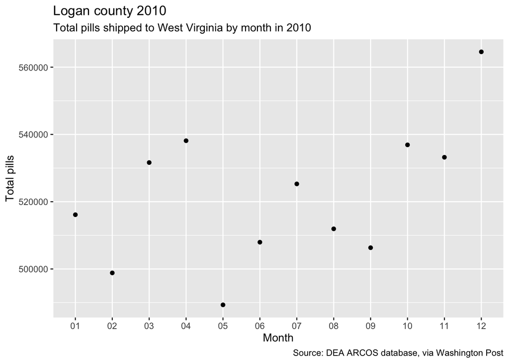

```r
west_virginia <- summarized_county_monthly(county="Logan", state="WV", key = key) %>%
clean_names()  %>%
filter(buyer_state == "WV", year=="2010")

ggplot(west_virginia) +
  geom_point(aes(month, dosage_unit)) +
  labs(x="Month", y="Total pills", title="Logan county 2010", subtitle = "Total pills shipped to West Virginia by month in 2010", caption = "Source: DEA ARCOS database, via Washington Post")
```

#The years 2006 and 2007 for Mingo county have significant dips from January to December. 2009 to 2011 rise in January.

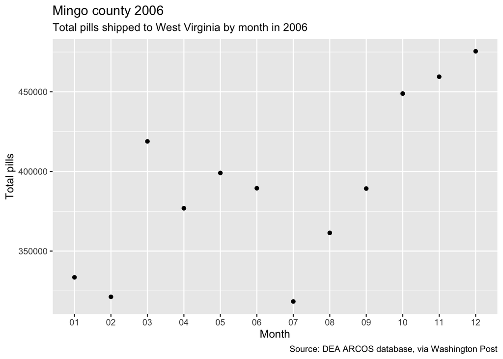

```r
west_virginia <- summarized_county_monthly(county="Mingo", state="WV", key = key) %>%
clean_names()  %>%
filter(buyer_state == "WV", year=="2006")

ggplot(west_virginia) +
  geom_point(aes(month, dosage_unit)) +
 labs(x="Month", y="Total pills", title="Mingo county 2006", subtitle = "Total pills shipped to West Virginia by month in 2006", caption = "Source: DEA ARCOS database, via Washington Post")
```

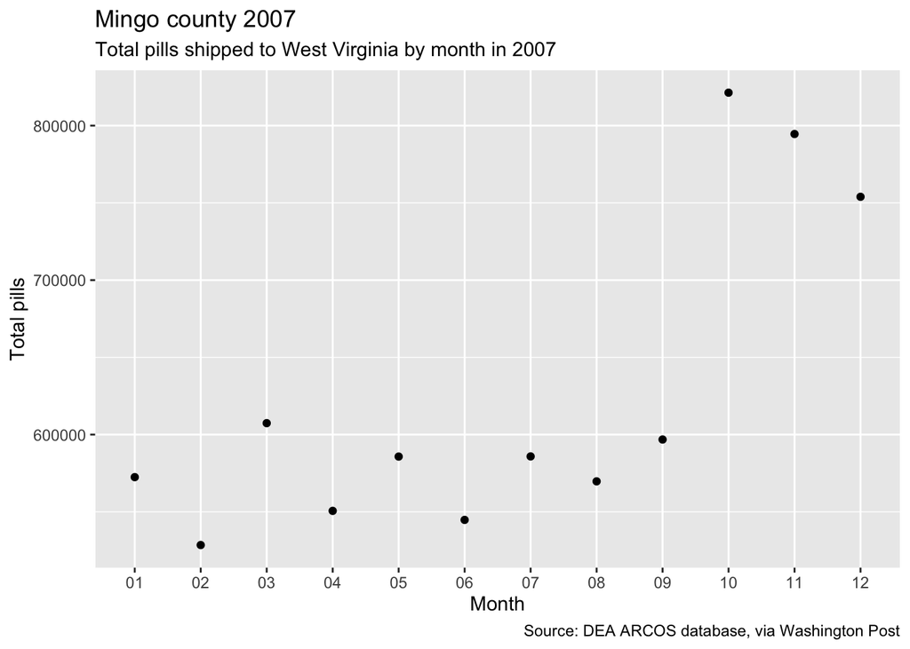

```r
west_virginia <- summarized_county_monthly(county="Mingo", state="WV", key = key) %>%
clean_names()  %>%
filter(buyer_state == "WV", year=="2007")

ggplot(west_virginia) +
  geom_point(aes(month, dosage_unit)) +
 labs(x="Month", y="Total pills", title="Mingo county 2007", subtitle = "Total pills shipped to West Virginia by month in 2007", caption = "Source: DEA ARCOS database, via Washington Post")
```

Below I provided an analysis of the top 3 states that were hit by the opiod crisis the hardest along with three states that were mostly unaffected by the opiod crisis.

TOP 3 STATES:

3. Does the dip in January seem to be consisten amoung states that were hit hard by the opioid crisis and those that weren’t hit as hard?

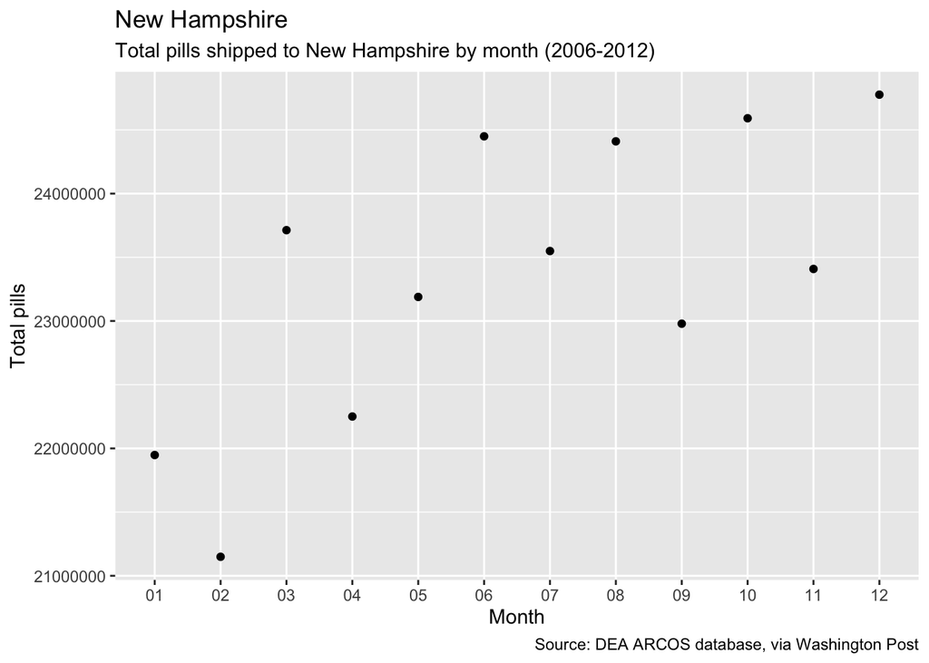

```r
ggplot(pills_state_month %>%
      group_by(buyer_state) %>%
      filter(buyer_state == "NH")
       ) +
  geom_point(aes(month, total_pills)) +
 labs(x="Month", y="Total pills", title="New Hampshire", subtitle = "Total pills shipped to New Hampshire by month (2006-2012)", caption = "Source: DEA ARCOS database, via Washington Post")
```

```r
pills_county_month %>%
      select(buyer_county, month, total_pills) %>%
      filter(buyer_county =="SULLIVAN")
```

```
## # A tibble: 72 x 3
##    buyer_county month total_pills
##    <chr>        <chr>       <dbl>
##  1 SULLIVAN     01         639040
##  2 SULLIVAN     02         680500
##  3 SULLIVAN     03         728500
##  4 SULLIVAN     04         689200
##  5 SULLIVAN     05         750620
##  6 SULLIVAN     06         773500
##  7 SULLIVAN     07         775100
##  8 SULLIVAN     08         751700
##  9 SULLIVAN     09         768660
## 10 SULLIVAN     10         782300
## # … with 62 more rows
```

```r
pills_county_month %>%
      select(buyer_county, month, total_pills) %>%
      filter(buyer_county =="STRAFFORD")
```

```
## # A tibble: 12 x 3
##    buyer_county month total_pills
##    <chr>        <chr>       <dbl>
##  1 STRAFFORD    01        2562460
##  2 STRAFFORD    02        2363260
##  3 STRAFFORD    03        2584400
##  4 STRAFFORD    04        2458890
##  5 STRAFFORD    05        2577900
##  6 STRAFFORD    06        2717270
##  7 STRAFFORD    07        2543730
##  8 STRAFFORD    08        2719190
##  9 STRAFFORD    09        2567520
## 10 STRAFFORD    10        2770300
## 11 STRAFFORD    11        2584570
## 12 STRAFFORD    12        2779220
```

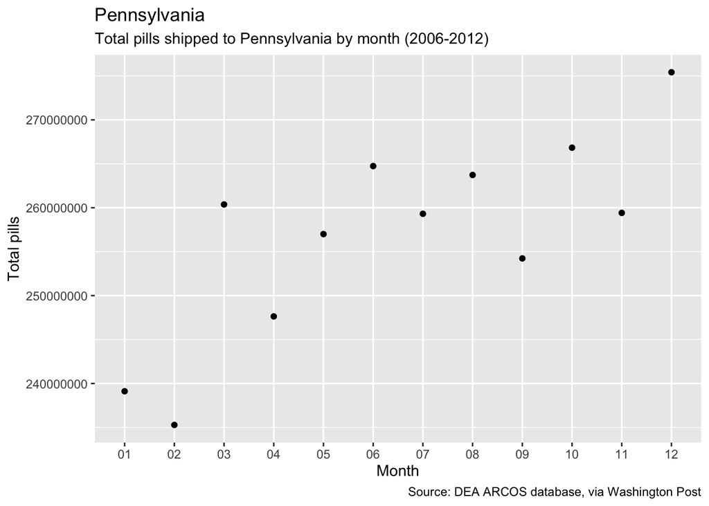

```r
ggplot(pills_state_month %>%
      group_by(buyer_state) %>%
      filter(buyer_state == "PA")
       ) +
  geom_point(aes(month, total_pills)) +
 labs(x="Month", y="Total pills", title="Pennsylvania", subtitle = "Total pills shipped to Pennsylvania by month (2006-2012)", caption = "Source: DEA ARCOS database, via Washington Post")
```

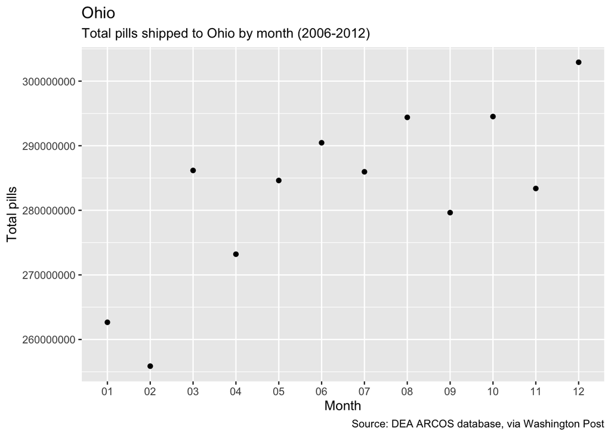

```r
ggplot(pills_state_month %>%
      group_by(buyer_state) %>%
      filter(buyer_state == "OH")
       ) +
  geom_point(aes(month, total_pills)) +
 labs(x="Month", y="Total pills", title="Ohio", subtitle = "Total pills shipped to Ohio by month (2006-2012)", caption = "Source: DEA ARCOS database, via Washington Post")
```

```r
pills_county_month %>%
      select(buyer_county, month, total_pills) %>%
      filter(buyer_county =="WOOD")
```

```
## # A tibble: 48 x 3
##    buyer_county month total_pills
##    <chr>        <chr>       <dbl>
##  1 WOOD         01        2360390
##  2 WOOD         02        2257410
##  3 WOOD         03        2535230
##  4 WOOD         04        2465170
##  5 WOOD         05        2523510
##  6 WOOD         06        2466515
##  7 WOOD         07        2636430
##  8 WOOD         08        2337370
##  9 WOOD         09        2431520
## 10 WOOD         10        2658870
## # … with 38 more rows
```

```r
pills_county_month %>%
      select(buyer_county, month, total_pills) %>%
      filter(buyer_county =="WAYNE")
```

```
## # A tibble: 192 x 3
##    buyer_county month total_pills
##    <chr>        <chr>       <dbl>
##  1 WAYNE        01         996770
##  2 WAYNE        02        1006240
##  3 WAYNE        03        1111640
##  4 WAYNE        04        1142115
##  5 WAYNE        05        1266080
##  6 WAYNE        06        1135690
##  7 WAYNE        07        1055320
##  8 WAYNE        08        1089920
##  9 WAYNE        09        1051330
## 10 WAYNE        10        1230220
## # … with 182 more rows
```

LOWEST 3 STATES

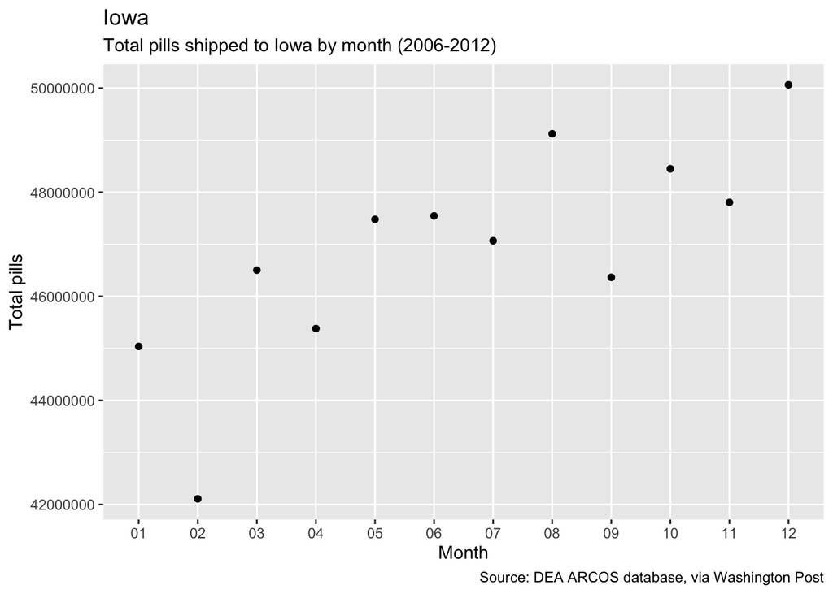

```r
ggplot(pills_state_month %>%
      group_by(buyer_state) %>%
      filter(buyer_state == "IA")
       ) +
  geom_point(aes(month, total_pills)) +
 labs(x="Month", y="Total pills", title="Iowa", subtitle = "Total pills shipped to Iowa by month (2006-2012)", caption = "Source: DEA ARCOS database, via Washington Post")
```

```r
pills_county_month %>%
      select(buyer_county, month, total_pills) %>%
      filter(buyer_county =="WRIGHT")
```

```
## # A tibble: 36 x 3
##    buyer_county month total_pills
##    <chr>        <chr>       <dbl>
##  1 WRIGHT       01         236130
##  2 WRIGHT       02         213730
##  3 WRIGHT       03         259060
##  4 WRIGHT       04         235060
##  5 WRIGHT       05         254600
##  6 WRIGHT       06         254830
##  7 WRIGHT       07         246860
##  8 WRIGHT       08         255800
##  9 WRIGHT       09         234900
## 10 WRIGHT       10         252700
## # … with 26 more rows
```

```r
pills_county_month %>%
      select(buyer_county, month, total_pills) %>%
      filter(buyer_county =="WORTH")
```

```
## # A tibble: 36 x 3
##    buyer_county month total_pills
##    <chr>        <chr>       <dbl>
##  1 WORTH        01         266220
##  2 WORTH        02         282820
##  3 WORTH        03         305700
##  4 WORTH        04         319130
##  5 WORTH        05         301630
##  6 WORTH        06         319160
##  7 WORTH        07         302960
##  8 WORTH        08         333020
##  9 WORTH        09         315020
## 10 WORTH        10         321730
## # … with 26 more rows
```

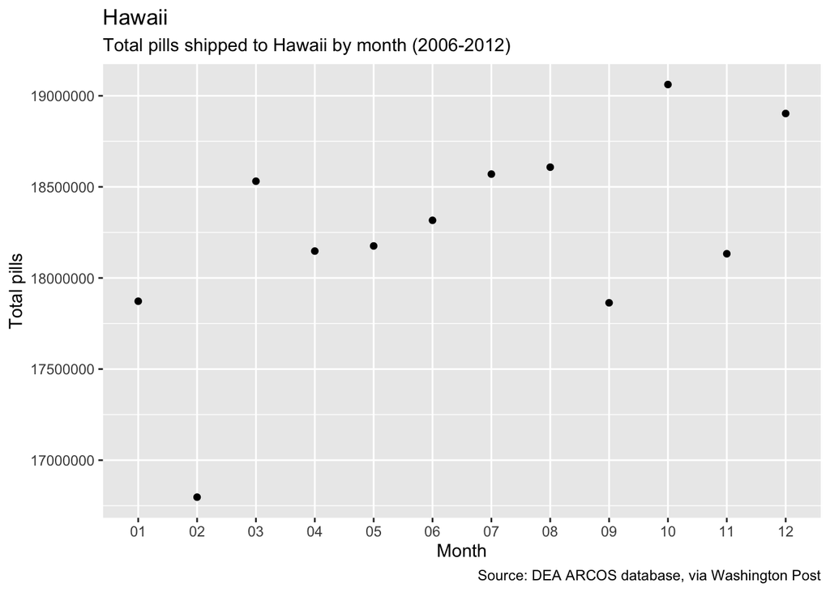

```r
ggplot(pills_state_month %>%
      group_by(buyer_state) %>%
      filter(buyer_state == "HI")
       ) +
  geom_point(aes(month, total_pills)) +
 labs(x="Month", y="Total pills", title="Hawaii", subtitle = "Total pills shipped to Hawaii by month (2006-2012)", caption = "Source: DEA ARCOS database, via Washington Post")
```

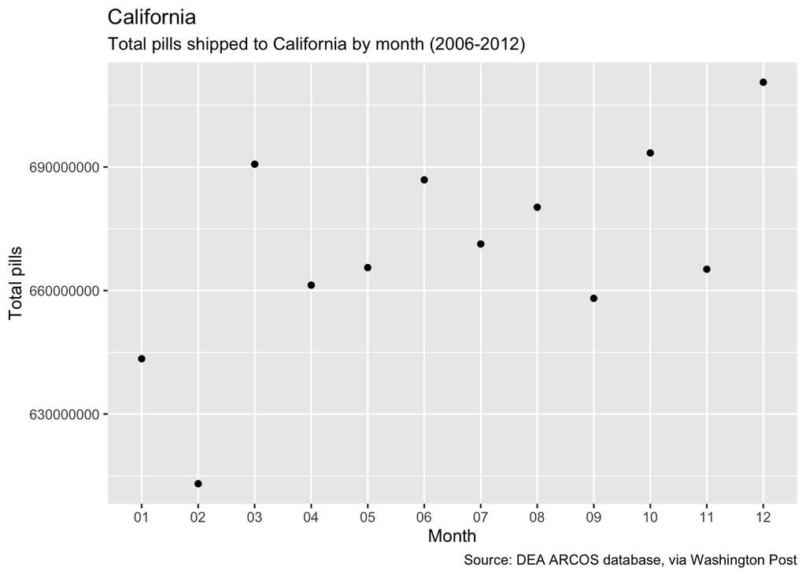

```r
ggplot(pills_state_month %>%
      group_by(buyer_state) %>%
      filter(buyer_state == "CA")
       ) +
  geom_point(aes(month, total_pills)) +
 labs(x="Month", y="Total pills", title="California", subtitle = "Total pills shipped to California by month (2006-2012)", caption = "Source: DEA ARCOS database, via Washington Post")
```

```r
pills_county_month %>%
      select(buyer_county, month, total_pills) %>%
      filter(buyer_county =="MONTEREY")
```

```
## # A tibble: 12 x 3
##    buyer_county month total_pills
##    <chr>        <chr>       <dbl>
##  1 MONTEREY     01       6572342
##  2 MONTEREY     02       6220330
##  3 MONTEREY     03       6988712
##  4 MONTEREY     04       6730275
##  5 MONTEREY     05       6731760
##  6 MONTEREY     06       7099150
##  7 MONTEREY     07       7018020
##  8 MONTEREY     08       7208263
##  9 MONTEREY     09       6806243
## 10 MONTEREY     10       7152666.
## 11 MONTEREY     11       6847551.
## 12 MONTEREY     12       7412511.
```

```r
pills_county_month %>%
      select(buyer_county, month, total_pills) %>%
      filter(buyer_county =="MONO")
```

```
## # A tibble: 12 x 3
##    buyer_county month total_pills
##    <chr>        <chr>       <dbl>
##  1 MONO         01         171950
##  2 MONO         02         163300
##  3 MONO         03         168825
##  4 MONO         04         150200
##  5 MONO         05         112800
##  6 MONO         06         127440
##  7 MONO         07         139630
##  8 MONO         08         141875
##  9 MONO         09         118800
## 10 MONO         10         119130
## 11 MONO         11         121500
## 12 MONO         12         149230
```

#It looks to me that the January opiod dip is solid amoung the states even those who were not much affected by the opioid crisis. The inconsistency in seeing the trend happens when you go county by county. Some counties within the states show the January trend while others don’t or show it to a small degree. The trend at the county level accounts for the variance in the difference between December and January when we look at the state level. Could it be that the small difference at the county level adds to a large level when we look at the state?

#For example, Mono in California (one of the least affected states) does not follow the trend of an opiod dip in January even though many of the other counties does.